# Fundamentals of Python

Alex Partner | School of Mathematics, Statistics and Actuarial Science

# 1 | Introduction to Python

Python is a highly popular language due to its versatility and capabilities.

## Using Python

We recommend that you use a [Jupyter Notebook](https://jupyter.org/try-jupyter/lab/index.html) when first starting to code in Python. This is an online Integrated Development Environment (IDE) which means that you do not need to download software to your computer. You can also easily save code to use on a different computer or submit for assignments.

[figure not shown]

Jupyter Lite IDE

All activities in this resource can be carried out in Jupyter Notebook. You can create new code blocks with the plus icon and run these blocks with the triangle icon. Outputs will be show directly underneath. You can also open new files with the tabs at the top of your screen. You can download a file by right-clicking the file in the file manager of the left-hand side of the screen.

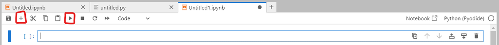

Jupyter Lite Controls

Once you have learnt the basics, you may choose to migrate to a desktop version by downloading Python on your computer and then use an IDE such as Visual Studio Code or PyCharm. A desktop version will allow you to program more computationally-heavy code.

## How to engage with these materials

Perhaps the best way to learn how to code is to solve problems. Almost every person who codes will rely on forums such as [Stack Overflow](https://stackoverflow.com/) and then adapt the suggested code to their needs. By adapting existing code, it forces you to understand why code works as well as learning the particular syntax structure.

As such, this resource has been designed as a set of structured exercises for you to work through independently. The exercises are designed to test specific aspects of coding skills and some explanation has been provided to help you to understand what is going on. We expect that you will need to use external help such as Stack Overflow as this reflects the coding experience.

**These resources are pitched at the level of a novice to Python.** However, if you have some familiarity with Python, it can still be beneficial to work through the exercises as revision or to consolidate knowledge.

## Useful syntax

Before getting started, it is useful to be aware of how basic Python syntax works. We will assume that you are typing code in a script or notebook rather than command line prompts for the entirety of this resource.

- Each command needs to be placed on a new line
- In some instances, we might choose to put multiple commands on the same line with a `;` separating them
- Python runs code sequentially (from top to bottom)
- Spaces between commands or lines are usually ignored by Python, but they may help with clarity
- Tabs are not ignored by Python so we should only use indentation for code sections such as functions or loops
- A `=` allows us to store values
- A `#` tells Python to ignore anything written after this on that line. This is useful for commenting code
- Python has some inbuilt function commands which accept inputs. We type the name of the function immediately followed by two brackets `(...)` where we place the input. For example, `print(...)`
- Python always starts counting from $0$. This means that the first item will have an index of `0`
- The index `a:b` will mean $a\leq x<b$ i.e., the upper index will not be included

# 2 | Python Syntax

## Storing values

We can store values to a **variable** in Python memory for us to use and manipulate later.

### Problem 1

> 1. Create a variable named `age` and assign the value `12` to it.
> 2. Create a variable named `name` and assign the string `George` to it.
> 3. Create a variable named `student` and assign the Boolean state `True` to it.
> 4. Print the statement using these variables as a formatted string. For example: “My name is [name] and I am [age] years old. It is [student] to say that I am a student.”

**Solutions**

```r
#Q1
age = 12

#Q2
name = "George"

#Q3
student = True

#Q4
print(f"My name is {name} and I am {age} years old. It is {student} to say that I am a student.") #the f before means that the string can be formatted with the values of the stored variables within a {...}
```

We have just seen that Python can store different types of values:

| Variable | Description |
| --- | --- |
| Numbers | `int` = integer, `float` = decimal, `complex` = complex number |
| Strings | We need to use `"` or `'` around the text to store |
| Booleans | `True` and `False` |

Once we have values stored within variables then we can recall or change them.

### Problem 2

> 1. Store the values `1`, `5` and `7` in variables named `a`, `b` and `c`, respectively.
> 2. Store the sum of `a`, `b` and `c` in the variable `s`
> 3. Print the variable `s` to verify that the correct values has been stored.
> 4. Now get Python to calculate the value of $2a-6$ and overwrite `a` with this new value.
> 5. Print the variables `a`, `b`, `c` and `s` on a single line

**Solutions**

```r
#Q1
a, b, c, = 1, 5, 7 #store respective values using a single line

#Q2
s = a + b + c

#Q3
print(s)

#Q4
a = 2*a - 6

#Q5
print(a, b, c, s)
```

## Lists

We can store multiple values to a single variable using a **list** which we create with square brackets `[...]` and separate elements with a comma `,`

### Problem 3

> 1. Store the values `"London"`, `"Paris"` and `"Tokyo"` to a list named `cities`
> 2. Change the second element of this list to “Madrid”.
> 3. Print the length of this list.

**Solutions**

```r
#Q1
cities = ["London", "Paris", "Tokyo"]
print(cities)

#Q2
cities[1] = "Madrid" #remember that Python starts counting from 0 so the second element has index 1
print(cities)

#Q2
print(len(cities))
```

Python is an object-orientated programming language. This means that when we build an object such as a list, we can apply methods to it using a `.`

### Problem 4

> 1. Store the values `"London"`, `"Paris"` and `"Tokyo"` to a list named `cities`
> 2. Append the element `"Madrid"` to the end of the `cities` list.
> 3. Insert the element `"Berlin"` at the second position of the `cities` list.
> 4. Store the values `"England"`, `"France"` and `"Japan"` to a list named `places`
> 5. Extend the `places` list to include the `cities` list.
> 6. Remove the element `"London"` from the `places` list.
> 7. Remove the element in the third position in the `places` list.
> 8. Sort the `places` list in reverse alphabetical order.

**Solutions**

```r
#Q1
cities = ["London", "Paris", "Tokyo"]
print(cities)

#Q2
cities.append("Madrid") #we are applying the append(...) method to the list
print(cities)

#Q3
cities.insert(1, "Berlin") #we insert this at the index 1 (second position)
print(cities)

#Q4
places = ["England", "France", "Japan"]
print(places)

#Q5
places.extend(cities)
print(places)

#Q6
places.remove("London")
print(places)

#Q7
places.pop(2) #index 2 is the third position
print(places)

#Q8
places.sort(reverse = True) #by default, it will be ascending so we need to reverse this
print(places)
```

## Tuples

A **tuple** is another way of storing multiple values. At first, it may naively appear to be the same as a list, however there is an important difference:

> We **cannot** add, remove or change elements after a tuple has been created.

Whereas a list can be modified after it has been created. This means that a tuple with a large number of elements will give better performance for certain operations than a list. Alternatively, we might use a tuple if elements will remain fixed such as coordinates, colour RGB values or database records.

We create a tuple with ordinary brackets `(...)` and elements separated with a comma `,`

### Problem 5

> 1. Create a tuple named `colours` with the elements `"red"`, `"green"`, `"blue"`, `"orange"` and `"yellow"`
> 2. Print the second, third and fourth elements of this tuple.
> 3. Unpack each element of this tuple to the variables `col1`, `col2`, `col3`, `col4` and `col5`
> 4. Duplicate every element of this tuple and overwrite the `colours` tuple with this.
> 5. Print the number of times that “blue” appears in this tuple.
> 6. Convert this tuple to a list.

**Solutions**

```r
#Q1
colours = ("red", "green", "blue", "orange", "yellow")

#Q2
#Note that the index starts from zero so we need the elements at index 1, 2, 3
#Also note that the upper index will not be extracted so 1:4 will extract 1, 2, 3 NOT 4
print(colours[1:4])

#Q3
(col1, col2, col3, col4, col5) = colours
print(col1) #etc

#Q4
colours = colours*2 #literally double (duplicate) every element

#Q5
f = colours.count("blue")
print(f)

#Q6
colours = list(colours) #we can convert back with tuple(...)
```

## Sets

A **set** is another way of storing multiple values. There is a difference between a set and a tuple or list, however:

> A set is **unordered** and we can only add or remove elements (we cannot change them).

Since a set is unordered, this means that each of its elements will not have an index. For this reason, we cannot have duplicate values within a set. Note that the values `True` and `1` are considered the same value (so equally are `False` and `0`).

We create a set using curly brackets `{...}` and a comma `,` separating elements.

### Problem 6

> 1. Create a set called `flavours` formed of the elements `"vanilla"`, `"strawberry"` and `"banana"`
> 2. Add the list `["mint", "raspberry"]` to the `flavours` set.
> 3. Remove `"strawberry"` from the `flavours` set.
> 4. Get Python to output `True` or `False` depending on whether the `flavours` set still contains `"banana"`
> 5. Create a set `A` formed of the odd numbers less than 10
> 6. Create a set `B` formed of the prime numbers less than 10
> 7. Return the elements found in the intersection of `A` and `B`

**Solutions**

```r
#Q1
flavours = {"vanilla", "strawberry", "banana"}

#Q2
flavours.update(["mint", "raspberry"])
print(flavours) #note this is still a set

#Q3
flavours.remove("strawberry")
print(flavours)

#Q4
print("banana" in flavours)

#Q5
A = {1, 3, 5, 7, 9}

#Q6
B = {2, 3, 5, 7}

#Q7
both = A.intersection(B)
print(both)
```

## Dictionaries

A dictionary is another way of storing multiple values, however it does it using key:value pairs. For example, suppose that we wish to store a country with its capital city then we might have:

| Key | Value |
| --- | --- |
| England | London |
| France | Paris |
| Spain | Madrid |

In other words, we need to have a country paired with its corresponding capital city.

Python dictionaries are ordered, changeable, but do not allow duplicates. We create a dictionary with curly brackets `{...}` and pairs separated with a comma `,`. Each pair takes the form `key : value` with a colon separating them in that order.

```r
mycountrydictionary = {
  "England" : "London",
  "France" : "Paris",
  "Spain" : "Madrid"
}
```

We can then get the capital city of any country:

```r
mycountrydictionary["France"]
```

Note that duplicates are not allowed so any new duplicate key will overwrite an existing one:

```r
mycountrydictionary = {
  "England" : "London",
  "France" : "Paris",
  "Spain" : "Madrid",
  "Spain" : "Barcelona"
}

mycountrydictionary["Spain"]
```

### Problem 7

> 1. Create a dictionary called `fruits` containing the following data:

| Fruit | Colour |
| --- | --- |
| apple | red |
| banana | yellow |
| plum | purple |
| grape | green |
| satsuma | orange |

> 2. Get the colour of a plum.
> 3. Change the colour of an apple to be green.
> 4. Update the possible colours of a grape to be a list containing the colours white, green, black and red.
> 5. Remove the satsuma key:value pair from the dictionary.
> 6. Print a list of all the keys within a dictionary.
> 7. Print a list of all the values within a dictionary.
> 8. Create a dictionary called `school1` which contains the following data:

| Key | Value |
| --- | --- |
| Location | London |
| Student Numbers | 245 |
| Staff Numbers | 36 |
| Funded | False |

> 9. Create a dictionary called `school2` which contains the following data:

| Key | Value |
| --- | --- |
| Location | Essex |
| Student Numbers | 584 |
| Staff Numbers | 60 |
| Funded | True |

> 10. Create a dictionary called `school3` which contains the following data:

| Key | Value |
| --- | --- |
| Location | Suffolk |
| Student Numbers | 1182 |
| Staff Numbers | 95 |
| Funded | True |

> 11. Create a dictionary called `schools` which contains the dictionaries `school1`, `school2` and `school3`
> 12. Extract the location of `school2` from `schools`

**Solutions**

```r
#Note the alternative methods to do the same thing

#Q1
fruits = dict(apple = "red", banana = "yellow", plum = "purple", grape = "green", satsuma = "orange")

#Q2
fruits.get("plum")

#Q3
fruits["apple"] = "green"
print(fruits)

#Q4
fruits["grape"] = ["white", "green", "black", "red"]
print(fruits)

#Q5
fruits.pop("satsuma")
print(fruits)

#Q6
k = fruits.keys()
k = list(k) #change to a list
print(k)

#Q7
v = fruits.values()
v = list(v) #change to a list
print(v)

#Q8
school1 = {"Location": "London",
           "Student Numbers": 245,
           "Staff Numbers": 36,
           "Funded": False
          }

#Q9
school2 = {"Location": "Essex",
           "Student Numbers": 584,
           "Staff Numbers": 60,
           "Funded": True
          }

#Q10
school3 = {"Location": "Suffolk",
           "Student Numbers": 1182,
           "Staff Numbers": 95,
           "Funded": True
          }

#Q11
schools = {"School 1": school1,
           "School 2": school2,
           "School 3": school3
          }

#Q12
loc = schools["School 2"]["Location"]
print(loc)
```

# 3 | Conditional Statements, Loops and Functions

## Conditional statements

A highly useful and fundamental tool in programming is to only run a section of code if a given condition is true. Python supports the given logical conditions to help with testing a statement:

| Condition | Syntax |
| --- | --- |
| Equal to | `==` |
| Not equal to | `!=` |
| Less than | `<` |
| Greater than | `>` |
| Less than or equal to | `<=` |
| Greater than or equal to | `>=` |

Python uses the keywords `if`, `elif` (else if) and `else`. Crucially, we need to use **indentation** to indicate the section of code to run. The syntax follows the form `if <statement is true> :` and might look something as below:

```r
a, b, c = 1, 2, 3

#Statement 1
if a > b:
  print("The value of a is larger than b") #we only run this if Statement 1 is true

#Statement 2
elif b > c:
  print("The value of b is larger than a and c") #we only run this if Statement 1 is false

#Statement 3
else:
  print("The value of c is larger than a and b") #we only run this if Statment 1 and 2 are false
```

We can check multiple conditions hold with the `and` and `or` operators:

> - The `and` operator means that **both** conditions must be true.
> - The `or` operator means that **either** condition must be true.

Finally, we may need to do tell Python to do nothing if a statement is true which we can do with the `pass` statement:

```r
a, b = 1, 2

if a == b:
  pass #We don't want Python to do anything if the numbers are equal
```

### Problem 8

> 1. A student’s grade on a particular test takes the form of a letter from A to F. The thresholds are given below:

| Percentage ($p$%) | Letter grade |
| --- | --- |
| $90\leq p\leq 100$ | A |
| $80\leq p<90$ | B |
| $70\leq p<80$ | C |
| $60\leq p<70$ | D |
| $50\leq p<60$ | E |
| $0\leq p<50$ | F |

> Write a Python code which takes a numeric percentage and then prints the output corresponding to the correct letter grade.
> 2. Write a Python code to determine if a year is a leap year. **Hint:** a leap year is divisible by 4, except if it is an end of century (e.g., 1900) in which case it needs to also be divisible by 400 (e.g., 2000).

**Solutions**

```r
#Q1
percent = 55.2

if percent >= 90:
    grade = "A"

elif percent >= 80:
    grade = "B"

elif percent >= 70:
    grade = "C"

elif percent >= 60:
    grade = "D"

elif percent >= 50:
    grade = "E"

else:
    grade = "F"

print(f"Your grade is: {grade}")

#Q2
year = 2024

if year % 4 == 0 and (year % 100 !=0 or year % 400 == 0):
    print(f"{year} IS a leap year")
else:
    print(f"{year} is NOT a leap year")
```

## Loops

A loop will repeat a section of code according to a particular condition. There are predominantly two types of loops in programming:

> **While loop:** this repeats a section of code *while* a particular condition is true.

> **For loop:** this repeats a section of code *for* a particular set of values.

We write a while loop using the similar syntax (including indentation) as we saw with conditional statements. A while loop requires us to have a variable which updates, otherwise the loop will run forever. We can increment a value with the `+=` operator and decrement a value with the `-=` operator. For example, to increment the value of `i` by 2 we would write `i += 2`

```r
i = 2

while i <= 10: #only run as long as i is less than or equal to 10
  print(i)
  i += 2 #increment i at the end of the loop
```

A for loop uses similar syntax (including indentation). A for loop allows us to loop through a range of values, for example:

```r
colours = ["red", "orange", "yellow", "green", "blue", "indigo", "violet"]
i = 1

for c in colours:
  print(f"The {i}th colour of the rainbow is {c}")
  i += 1
```

### Problem 9

> 1. Write a Python code which prints the individual letters of the word `"Tokyo"`
> 2. Write a Python code which prints the elements of the list `["Bag", "Glasses", "Bottle", "Wallet"]`
> 3. Write a Python code which prints the odd numbers from 5 to 21 (inclusive).
> 4. Write a Python code which prints one 1, two 2s, three 3s, four 4s, etc. as seen in the following diagram:

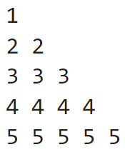

> 5. The factorial of a number ($n!$) is defined as the product of consecutive integers from 1 to the number itself. For example $5!=5\times 4\times 3\times 2\times 1=120$

>    Write a Python code which prints the first 10 factorial numbers. You must not use a factorial function in Python.
> 6. Create the following list which contains sublists: `[["everest", "olympus", "fuji"], ["apple", "banana", "orange"], ["macbeth", "hamlet", "othello"]]`

>    By using a for loop on this list, write a Python code which creates a list of all of the letters that are used within the elements. Sort this list into alphabetical order and remove duplicate letters.

**Solutions**

```r
#Q1
for i in "Tokyo":
    print(i)

#Q2
for i in ["Bag", "Glasses", "Bottle", "Wallet"]:
    print(i)

#Q3
for i in range(5, 22, 2): #note the upper limit (22) is not included
    print(i)

#Q4
for row in range(6):
    for col in range(row + 1):
        print("*", end=" ") #end tells Python not to force a new line
    print() #print nothing to force a new line

#Q5
for num in range(1, 6):
    for i in range(num):
        print(num, end=" ")
    print()

#Q6
for i in range(1, 11):
    fact = 1 #reset factorial
    for j in range(1, i + 1):
        fact = fact * j
    print(fact)

#Q7
oldlist = [["everest", "olympus", "fuji"], ["apple", "banana", "orange"], ["macbeth", "hamlet", "othello"]]
newlist = []
for mainlist in oldlist:
    for sublist in mainlist:
        for letter in sublist:
            newlist.append(letter)

newlist.sort() #sort alphabetically
newlist = list(set(newlist)) #remove duplicates by converting to a set (and then back to a list)

print(newlist)
```